# Python数据处理

## 05. pandas

主讲人：丁平尖

## Pandas

- 开源数据分析工具库
  - 底层操作使用Cython实现（Cython=C+Python，通常更快）数据库类结构，与R中可用的结构大致相似
  - 针对最常见的操作进行了优化。
    - 例如，向量化操作、表格行上的操作
- pandas是一个Python包，提供快速、灵活且富有表现力的数据结构，旨在使处理“关系型”数据变得既简单又直观。
  - https://pandas.pydata.org/docs/

## 安装pandas

- anaconda
  - conda install pandas
- 镜像
  - pip
    - pip install -i https://mirrors.tuna.tsinghua.edu.cn/pypi/web/simple pandas
  - conda
    - 添加镜像源
      - conda config --add channels https://mirrors.tuna.tsinghua.edu.cn/anaconda/pkgs/main/
    - 更新包索引
      - conda update --all
    - 安装指定包
      - conda install pandas

## 基本数据结构

- Series：表示一维标记数组
  - 标记只是意味着有一个索引进入数组
  - 支持向量化操作
- DataFrame：行的表格，具有标记列
  - 像电子表格或R数据框
  - 支持numpy ufuncs（提供的数据是数字）

## pandas：Series

```python
# 默认情况下，索引是整数，从0开始
import pandas as pd
import numpy as np
numbers = np.random.randn(5)
s = pd.Series(numbers)
s
```

```
0    0.423218
1   -0.489838
2    0.855377
3    0.886844
4   -0.061101
dtype: float64
```

```python
# 可以从任何类似数组的结构（例如，numpy数组、Python列表、字典）创建pandas Series
# 可以用其他集合作为索引
idx = ['a', 'b', 'c', 'd', 'e']
s = pd.Series(numbers, index=idx)
s
```

```
a    0.423218
b   -0.489838
c    0.855377
d    0.886844
e   -0.061101
dtype: float64
```

## pandas：Series

```python
# 可以从字典创建一个Series。键成为索引
d = {'a': 0, 'b' : 1, 'c': 2}
s = pd.Series(d)
s
```

```
a    0
b    1
c    2
dtype: int64
```

```python
# Series支持切片，但不支持负索引。
s = pd.Series([2, 3, 5, 7, 11])
s[1:3]
```

```
1    3
2    5
dtype: int64
```

```python
s[-1]
```

[output not shown]

## pandas: Series

- pandas Series中的索引不必是唯一的。

```python
s = pd.Series([2, 3, 5, 7, 11], index=['a', 'a', 'a', 'a', 'a'])
s['a']
```

```
a     2
a     3
a     5
a     7
a    11
dtype: int64
```

```python
# Series对象就像np.ndarray对象一样，因此它们支持所有相同类型的切片操作
s[s>3]
```

```
a     5
a     7
a    11
dtype: int64
```

```python
d = {'dog': 2, 'cat':3, 'bird':5}
s = pd.Series(d)
s ** 2
```

```
dog      4
cat      9
bird    25
dtype: int64
```

## pandas:Series

- Series对象是类似字典的，我们可以通过它们的键访问和更新元素。

```python
s['dog'] = 1
s
```

```
dog     1
cat     3
bird    5
dtype: int64
```

## pandas: Series

- Series有一个可选的name属性。设置后，可以使用rename方法更改name属性。
- 当我们开始讨论DataFrames时，这将变得特别有用，因为这些name属性将成为列名。

```python
s.name = 'animals'
s
```

```
dog     1
cat     3
bird    5
Name: animals, dtype: int64
```

```python
s.rename('mammal')
```

```
dog     1
cat     3
bird    5
Name: mammal, dtype: int64
```

## Mapping and linking Series values

- Series map方法的工作方式类似于Python的map函数。它接受一个函数并将其应用于每个元素。

```python
s = pd.Series(['dog', 'goat', 'skunk'])
s.map(lambda s:len(s))
```

```
0    3
1    4
2    5
dtype: int64
```

```python
s = pd.Series(['fruit', 'animal', 'animal', 'fruit', 'fruit'], index=['apple', 'cat', 'goat', 'banana', 'kiwi'])
s
```

```
apple      fruit
cat       animal
goat      animal
banana     fruit
kiwi       fruit
dtype: object
```

```python
t = pd.Series({'fruit':0, 'animal':1})
t
```

```
fruit     0
animal    1
dtype: int64
```

```python
s.map(t)
```

```
apple     0
cat       1
goat      1
banana    0
kiwi      0
dtype: int64
```

## pandas: DataFrames

- pandas的基本单位
  - 类似于R数据框(data.frame)
- 二维结构（即，行和列）
  - 列可能是不同的类型
- 可以从许多不同的对象创建
  - {ndarrays, Python列表，字典，Series}形成的字典
  - ndarray
  - Series

```python
# 从字典创建DataFrame，键成为列名。值成为字典的行。
# 对于给定列未指定的行，接收NaN。
d = {'A':pd.Series([1,2,3], index=['cat','dog','bird']),
    'B':{'cat':3.14, 'dog':2.718, 'bird':1.618, 'goat':0.5772}}
df = pd.DataFrame(d)
df
```

|  | A | B |
| --- | --- | --- |
| bird | 3.0 | 1.6180 |
| cat | 1.0 | 3.1400 |
| dog | 2.0 | 2.7180 |
| goat | NaN | 0.5772 |

```python
d = {'Undergrad' : pd.Series(['UMich', 'Stanford', 'Princeton', 'Columbia'],
                             index=['Ford', 'Hoover', 'Wilson', 'Obama']),
     'PhD' : {'Wilson':'Johns Hopkins'},
     'JD' : {'Ford':'Yale','Obama':'Harvard'},
     'Terms': pd.Series([1,1,2,2]) }
presidents = pd.DataFrame(d)
presidents
```

|  | Undergrad | PhD | JD | Terms |
| --- | --- | --- | --- | --- |
| Ford | UMich | NaN | Yale | NaN |
| Hoover | Stanford | NaN | NaN | NaN |
| Obama | Columbia | NaN | Harvard | NaN |
| Wilson | Princeton | Johns Hopkins | NaN | NaN |
| 0 | NaN | NaN | NaN | 1.0 |
| 1 | NaN | NaN | NaN | 1.0 |
| 2 | NaN | NaN | NaN | 2.0 |
| 3 | NaN | NaN | NaN | 2.0 |

## pandas DataFrames：行/列名称

- 行和列名称可以作为DataFrame的索引和列属性分别访问，两者都返回为pandas Index对象。

```python
presidents.columns
```

```
Index(['Undergrad', 'PhD', 'JD', 'Terms'], dtype='object')
```

```python
presidents.index
```

```
Index(['Ford', 'Hoover', 'Obama', 'Wilson', 0, 1, 2, 3], dtype='object')
```

## pandas DataFrames：访问/添加列

- DataFrame的行为类似于字典，其键是列名，值是Series。
- 像字典一样，我们可以创建新的键值对。

```python
d = {'Undergrad' : pd.Series(['UMich', 'Stanford', 'Princeton', 'Columbia'],
                             index=['Ford', 'Hoover', 'Wilson', 'Obama']),
     'PhD' : {'Wilson':'Johns Hopkins'},
     'JD' : {'Ford':'Yale','Obama':'Harvard'},
     'Terms': pd.Series([1,1,2,2], index=['Ford', 'Hoover', 'Wilson', 'Obama']) }
presidents = pd.DataFrame(d)
presidents['Nobels'] = [0,0,1,1]
presidents
```

|  | Undergrad | PhD | JD | Terms | Nobels |
| --- | --- | --- | --- | --- | --- |
| Ford | UMich | NaN | Yale | 1 | 0 |
| Hoover | Stanford | NaN | NaN | 1 | 0 |
| Obama | Columbia | NaN | Harvard | 2 | 1 |
| Wilson | Princeton | Johns Hopkins | NaN | 2 | 1 |

```python
# 标量在行中传播播。
presidents['Fields Medals'] = 0
presidents
```

|  | Undergrad | PhD | JD | Terms | Nobels | Fields Medals |
| --- | --- | --- | --- | --- | --- | --- |
| Ford | UMich | NaN | Yale | 1 | 0 | 0 |
| Hoover | Stanford | NaN | NaN | 1 | 0 | 0 |
| Obama | Columbia | NaN | Harvard | 2 | 1 | 0 |
| Wilson | Princeton | Johns Hopkins | NaN | 2 | 1 | 0 |

## pandas DataFrames：删除列

```python
del presidents['Fields Medals']
presidents
```

|  | Undergrad | PhD | JD | Terms | Nobels |
| --- | --- | --- | --- | --- | --- |
| Ford | UMich | NaN | Yale | 1 | 0 |
| Hoover | Stanford | NaN | NaN | 1 | 0 |
| Obama | Columbia | NaN | Harvard | 2 | 1 |
| Wilson | Princeton | Johns Hopkins | NaN | 2 | 1 |

## pandas DataFrames：索引和选择

```python
# df.loc按其行标签选择行。df.iloc按其整数行标签（从0开始）选择行。
presidents.loc['Obama']
```

```
Undergrad    Columbia
PhD               NaN
JD            Harvard
Terms               2
Nobels              1
Name: Obama, dtype: object
```

```python
presidents.iloc[2]
```

```
Undergrad    Columbia
PhD               NaN
JD            Harvard
Terms               2
Nobels              1
Name: Obama, dtype: object
```

```python
# 多行
presidents.iloc[1:3], presidents[1:3]
```

```
(       Undergrad  PhD       JD  Terms  Nobels
 Hoover  Stanford  NaN      NaN      1       0
 Obama   Columbia  NaN  Harvard      2       1,
        Undergrad  PhD       JD  Terms  Nobels
 Hoover  Stanford  NaN      NaN      1       0
 Obama   Columbia  NaN  Harvard      2       1)
```

```python
# 按其名称选择列。
presidents['Undergrad']
```

```
Ford          UMich
Hoover     Stanford
Obama      Columbia
Wilson    Princeton
Name: Undergrad, dtype: object
```

```python
# 获得多列
presidents[['Undergrad', 'PhD']]
```

|  | Undergrad | PhD |
| --- | --- | --- |
| Ford | UMich | NaN |
| Hoover | Stanford | NaN |
| Obama | Columbia | NaN |
| Wilson | Princeton | Johns Hopkins |

```python
# 布尔表达式选择行
type(presidents['Terms']<2), presidents[presidents['Terms']<2]
```

```
(pandas.core.series.Series,
        Undergrad  PhD    JD  Terms  Nobels
 Ford       UMich  NaN  Yale      1       0
 Hoover  Stanford  NaN   NaN      1       0)
```

## DataFrame的算术

```python
df1 = pd.DataFrame(np.random.randn(8, 4), columns=['A', 'B', 'C', 'D'])
df2 = pd.DataFrame(np.random.randn(5, 3), columns=['A', 'B', 'C'])
df1+df2
```

|  | A | B | C | D |
| --- | --- | --- | --- | --- |
| 0 | 3.674877 | 1.013402 | 2.442386 | NaN |
| 1 | -0.224082 | 0.658016 | -0.229887 | NaN |
| 2 | 1.283483 | -0.970610 | -0.261253 | NaN |
| 3 | -2.611369 | 1.511940 | 1.579408 | NaN |
| 4 | 0.354213 | -1.356983 | 0.381391 | NaN |
| 5 | NaN | NaN | NaN | NaN |
| 6 | NaN | NaN | NaN | NaN |
| 7 | NaN | NaN | NaN | NaN |

```python
df = pd.DataFrame(np.random.randn(4, 2), columns=['A', 'B'])
df
```

|  | A | B |
| --- | --- | --- |
| 0 | -0.458210 | 0.660018 |
| 1 | 1.586089 | 0.266234 |
| 2 | 0.206351 | 1.065654 |
| 3 | -0.450068 | -0.274079 |

```python
df - df.iloc[0]
```

|  | A | B |
| --- | --- | --- |
| 0 | 0.000000 | 0.000000 |
| 1 | 2.044299 | -0.393784 |
| 2 | 0.664560 | 0.405636 |
| 3 | 0.008142 | -0.934097 |

## DataFrame的算术

```python
print((df>0).any())
print('*************************')
print((df>0).all())
```

```
A    True
B    True
dtype: bool
A    False
B    False
dtype: bool
```

```python
# values属性将dataframe中的元素存储在一个numpy数组中。
df.values
```

```
array([[-0.45820979,  0.66001809],
       [ 1.58608942,  0.26623444],
       [ 0.2063507 ,  1.0656545 ],
       [-0.45006761, -0.27407931]])
```

## DataFrame的算术

```python
df.T @ df
```

|  | A | B |
| --- | --- | --- |
| A | 2.970777 | 0.463098 |
| B | 0.463098 | 1.717244 |

```python
df * df
```

|  | A | B |
| --- | --- | --- |
| 0 | 0.209956 | 0.435624 |
| 1 | 2.515680 | 0.070881 |
| 2 | 0.042581 | 1.135620 |
| 3 | 0.202561 | 0.075119 |

## 删除NaN

- DataFrame dropna方法删除包含NaN的行或列。

```python
presidents.dropna(axis=0)
```

|  | Undergrad | PhD | JD | Terms | Nobels |
| --- | --- | --- | --- | --- | --- |

```python
presidents.dropna(axis=1)
```

|  | Undergrad | Terms | Nobels |
| --- | --- | --- | --- |
| Ford | UMich | 1 | 0 |
| Hoover | Stanford | 1 | 0 |
| Obama | Columbia | 2 | 1 |
| Wilson | Princeton | 2 | 1 |

## 读写文件

- https://pandas.pydata.org/pandas-docs/stable/user_guide/io.html

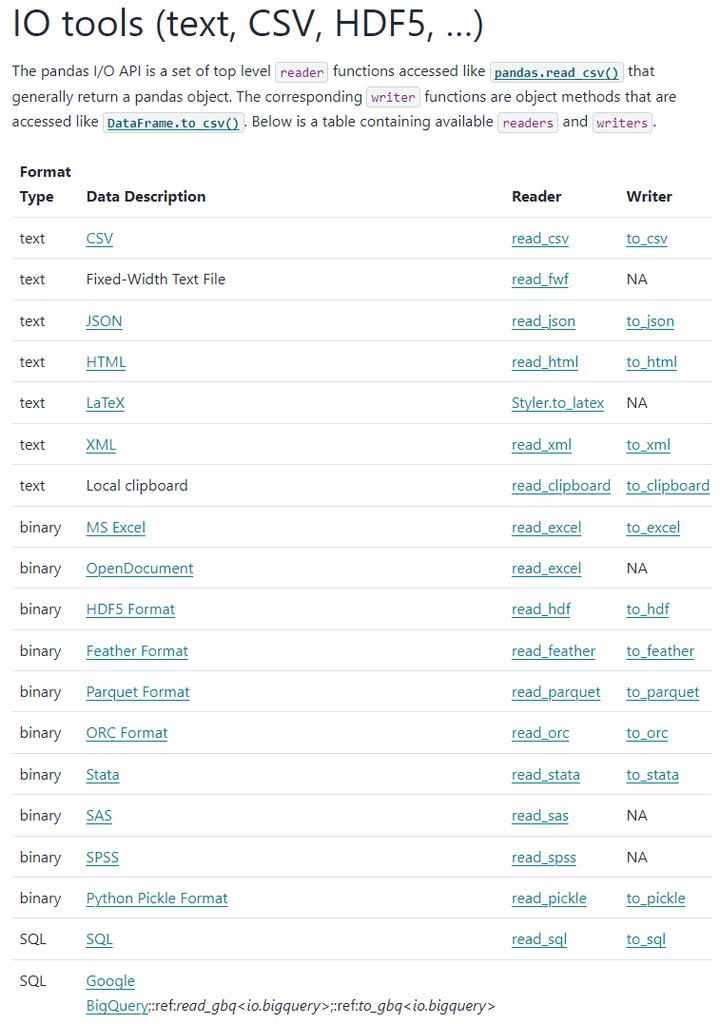

## 总结DataFrame

```python
baseball = pd.read_csv("baseball.csv")
# head()方法显示DataFrame的前几行）。tail()显示最后几行。
baseball.head(5)
```

|  | id | year | stint | team | lg | g | ab | r | h | X2b | ... | rbi | sb | cs | bb | so | ibb | hbp | sh | sf | gidp |
| --- | --- | --- | --- | --- | --- | --- | --- | --- | --- | --- | --- | --- | --- | --- | --- | --- | --- | --- | --- | --- | --- |
| 4 | ansonca01 | 1871 | 1 | RC1 | NaN | 25 | 120 | 29 | 39 | 11 | ... | 16.0 | 6.0 | 2.0 | 2 | 1.0 | NaN | NaN | NaN | NaN | NaN |
| 44 | forceda01 | 1871 | 1 | WS3 | NaN | 32 | 162 | 45 | 45 | 9 | ... | 29.0 | 8.0 | 0.0 | 4 | 0.0 | NaN | NaN | NaN | NaN | NaN |
| 68 | mathebo01 | 1871 | 1 | FW1 | NaN | 19 | 89 | 15 | 24 | 3 | ... | 10.0 | 2.0 | 1.0 | 2 | 0.0 | NaN | NaN | NaN | NaN | NaN |
| 99 | startjo01 | 1871 | 1 | NY2 | NaN | 33 | 161 | 35 | 58 | 5 | ... | 34.0 | 4.0 | 2.0 | 3 | 0.0 | NaN | NaN | NaN | NaN | NaN |
| 102 | suttoez01 | 1871 | 1 | CL1 | NaN | 29 | 128 | 35 | 45 | 3 | ... | 23.0 | 3.0 | 1.0 | 1 | 0.0 | NaN | NaN | NaN | NaN | NaN |

5 rows × 22 columns

## DataFrame上的统计操作

```python
df.mean(axis=0) # 列的均值
```

```
A    0.221041
B    0.429457
dtype: float64
```

```python
df.mean(axis=1) # 行的均值
```

```
0    0.100904
1    0.926162
2    0.636003
3   -0.362073
dtype: float64
```

## 按行和列函数：apply()

- DataFrame.apply()接受一个函数，并将其应用于DataFrame的每一列。
- 轴参数默认为0（按列）。更改为1以按行应用。

```python
df.apply(np.mean, axis=0)
```

```
A    0.221041
B    0.429457
dtype: float64
```

```python
df.apply(np.mean, axis=1)
```

```
0    0.100904
1    0.926162
2    0.636003
3   -0.362073
dtype: float64
```

```python
df.apply(np.exp)
```

|  | A | B |
| --- | --- | --- |
| 0 | 0.632415 | 1.934827 |
| 1 | 4.884610 | 1.305041 |
| 2 | 1.229184 | 2.902738 |
| 3 | 0.637585 | 0.760272 |

## 聚合数据

- agg()提供函数列表将分别将每个函数应用于DataFrame的每一列，每个函数在结果DataFrame中获得一行

```python
tsdf = pd.DataFrame(np.random.randn(10, 3),
                    columns=['DOW', 'NASDAQ', 'S&P500'],
                    index=pd.date_range('1/1/2000', periods=10))
tsdf.head()
```

|  | DOW | NASDAQ | S&P500 |
| --- | --- | --- | --- |
| 2000-01-01 | -1.111677 | 0.768413 | -0.143206 |
| 2000-01-02 | 0.009493 | 0.068919 | 0.430048 |
| 2000-01-03 | -1.230109 | 0.183881 | -2.149546 |
| 2000-01-04 | 0.307812 | -0.182283 | 0.667303 |
| 2000-01-05 | -1.371142 | 1.114009 | -1.048906 |

```python
import warnings
warnings.filterwarnings('ignore')
tsdf.agg([np.median, np.mean, np.std])
```

|  | DOW | NASDAQ | S&P500 |
| --- | --- | --- | --- |
| median | -0.104625 | 0.238541 | -0.465609 |
| mean | -0.171084 | 0.181594 | -0.558840 |
| std | 0.885533 | 0.824707 | 0.918165 |

```python
# agg()可以接受一个字典，其键是列名，值是函数。
tsdf.agg({'DOW':'mean',
          'NASDAQ':'median',
          'S&P500':'max'})
```

```
DOW      -0.171084
NASDAQ    0.238541
S&P500    0.667303
dtype: float64
```

## 逐元素函数应用

- applymap类似于Python的map函数（和Series map方法）。将其参数函数应用于DataFrame的每个元素。

```python
df = pd.DataFrame({'A': ['cat', 'dog', 'bird'],
                   'B': ['unicorn','chupacabra','pixie']})
df.applymap(lambda s: s.upper())
```

|  | A | B |
| --- | --- | --- |
| 0 | CAT | UNICORN |
| 1 | DOG | CHUPACABRA |
| 2 | BIRD | PIXIE |

## Series和DataFrames的迭代

```python
s
```

```
apple      fruit
cat       animal
goat      animal
banana     fruit
kiwi       fruit
dtype: object
```

```python
for i in s:
    print(i)
```

```
fruit
animal
animal
fruit
fruit
```

```python
tsdf.head()
```

|  | DOW | NASDAQ | S&P500 |
| --- | --- | --- | --- |
| 2000-01-01 | -1.111677 | 0.768413 | -0.143206 |
| 2000-01-02 | 0.009493 | 0.068919 | 0.430048 |
| 2000-01-03 | -1.230109 | 0.183881 | -2.149546 |
| 2000-01-04 | 0.307812 | -0.182283 | 0.667303 |
| 2000-01-05 | -1.371142 | 1.114009 | -1.048906 |

```python
for i in tsdf:
    print(i)
```

```
DOW
NASDAQ
S&P500
```

## 计算协方差

- cov方法计算一个Series与另一个Series之间的协方差。
- cov方法也由DataFrame支持，但会计算得到一个新的DataFrame，包含列之间的协方差。

[figure not shown]

```python
s1 = pd.Series(np.random.randn(1000))
s2 = pd.Series(np.random.randn(1000))
s1.cov(s2)
```

```
-0.003137610481467702
```

```python
tsdf.head(3)
```

|  | DOW | NASDAQ | S&P500 |
| --- | --- | --- | --- |
| 2000-01-01 | -1.111677 | 0.768413 | -0.143206 |
| 2000-01-02 | 0.009493 | 0.068919 | 0.430048 |
| 2000-01-03 | -1.230109 | 0.183881 | -2.149546 |

```python
tsdf.cov()
```

|  | DOW | NASDAQ | S&P500 |
| --- | --- | --- | --- |
| DOW | 0.784169 | -0.374583 | 0.382336 |
| NASDAQ | -0.374583 | 0.680142 | -0.046436 |
| S&P500 | 0.382336 | -0.046436 | 0.843026 |

## 成对相关性

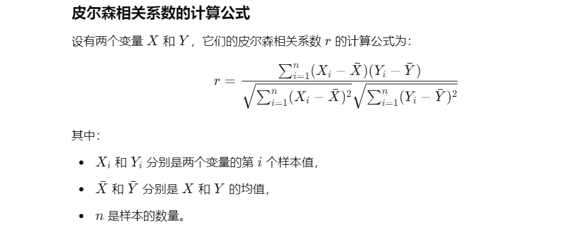

```python
tsdf.corr(method='spearman')
```

|  | DOW | NASDAQ | S&P500 |
| --- | --- | --- | --- |
| DOW | 1.000000 | -0.321212 | 0.563636 |
| NASDAQ | -0.321212 | 1.000000 | -0.151515 |
| S&P500 | 0.563636 | -0.151515 | 1.000000 |

## 对数据进行排名

- rank方法返回一个新的Series，其值是数据的排名。

```python
import pandas as pd
import numpy as np
s = pd.Series(np.random.randn(5), index=list('abcde'))
s
```

```
a   -1.178760
b    0.219868
c    0.100833
d    0.780885
e    2.962853
dtype: float64
```

```python
s.rank()
```

```
a    1.0
b    3.0
c    2.0
d    4.0
e    5.0
dtype: float64
```

```python
tsdf.rank(axis=0)
```

|  | DOW | NASDAQ | S&P500 |
| --- | --- | --- | --- |
| 2000-01-01 | 3.0 | 8.0 | 7.0 |
| 2000-01-02 | 6.0 | 4.0 | 9.0 |
| 2000-01-03 | 2.0 | 5.0 | 1.0 |
| 2000-01-04 | 8.0 | 3.0 | 10.0 |
| 2000-01-05 | 1.0 | 9.0 | 3.0 |
| 2000-01-06 | 9.0 | 10.0 | 5.0 |
| 2000-01-07 | 5.0 | 7.0 | 4.0 |
| 2000-01-08 | 10.0 | 1.0 | 6.0 |
| 2000-01-09 | 4.0 | 2.0 | 2.0 |
| 2000-01-10 | 7.0 | 6.0 | 8.0 |

```python
tsdf.rank(axis=1)
```

|  | DOW | NASDAQ | S&P500 |
| --- | --- | --- | --- |
| 2000-01-01 | 1.0 | 3.0 | 2.0 |
| 2000-01-02 | 1.0 | 2.0 | 3.0 |
| 2000-01-03 | 2.0 | 3.0 | 1.0 |
| 2000-01-04 | 2.0 | 1.0 | 3.0 |
| 2000-01-05 | 1.0 | 3.0 | 2.0 |
| 2000-01-06 | 2.0 | 3.0 | 1.0 |
| 2000-01-07 | 2.0 | 3.0 | 1.0 |
| 2000-01-08 | 3.0 | 1.0 | 2.0 |
| 2000-01-09 | 3.0 | 2.0 | 1.0 |
| 2000-01-10 | 1.0 | 3.0 | 2.0 |

## 分组(group by)：重新组织数据

- “分组”操作是数据库中的一个概念
- 根据某些标准拆分数据,对不同的拆分应用函数
- 将结果合并到一个单一的数据结构中
- 基本对象：pandas GroupBy对象

```python
df = pd.DataFrame({'A' : ['plant', 'animal', 'plant', 'plant'],
                   'B' : ['apple', 'goat', 'kiwi', 'grape'],
                   'C' : np.random.randn(4),
                   'D' : np.random.randn(4)})
df
```

|  | A | B | C | D |
| --- | --- | --- | --- | --- |
| 0 | plant | apple | -0.585502 | 0.214857 |
| 1 | animal | goat | -1.446204 | -1.042365 |
| 2 | plant | kiwi | 0.774599 | -0.545185 |
| 3 | plant | grape | -0.851527 | -1.206412 |

```python
df.groupby('A')
```

```
<pandas.core.groupby.generic.DataFrameGroupBy object at 0x00000178706A9790>
```

```python
# 在这个例子中，我们根据列‘A’进行拆分，
# 它有两个值：‘plant’和‘animal’,
# 所以groups字典有两个键。
df.groupby('A').groups
```

```
{'animal': [1], 'plant': [0, 2, 3]}
```

## 分组：聚合

```python
# 在组‘A’上拆分，然后在每个组内计算平均值。
# 注意，对于不支持平均值的列将被移除，所以列‘B’不会出现在结果中。
df.groupby('A')[['C', 'D']].mean()
```

| A | C | D |
| --- | --- | --- |
| animal | -1.446204 | -1.042365 |
| plant | -0.220810 | -0.512247 |

```python
# 构建一个层次化索引的Series（即，多索引），记录（虚构的）按专业和惯用手的学生分数。
arrs = [['math', 'math', 'econ', 'econ', 'stats', 'stats'],
          ['left', 'right', 'left', 'right', 'left', 'right']]
index = pd.MultiIndex.from_arrays(arrs, names=['major', 'handedness'])
s = pd.Series(np.random.randn(6), index=index)
s
```

```
major  handedness
math   left         -2.053607
       right        -0.469359
econ   left          0.678029
       right         0.947858
stats  left          0.273756
       right         0.061540
dtype: float64
```

```python
# 假设我想在忽略惯用手的情况下按专业得到平均分数。
# 按层次结构的0级（即，‘major’）进行分组，并取平均值
s.groupby('major').mean()
```

```
major
econ     0.812944
math    -1.261483
stats    0.167648
dtype: float64
```

## 转换数据

```python
import pandas as pd
df = pd.DataFrame({
    'A': ['a', 'a', 'b', 'b', 'c', 'c'],
    'B': [1, 3, 3, 4, 5, 6],
})
zscore = lambda x: (x - x.mean()) / x.std()

# 对数据框架进行分组，并对分组后的数据进行转换
df['B_mean'] = df.groupby('A')['B'].transform('mean')
df['B_std'] = df.groupby('A')['B'].transform('std')
df['Z_Score'] = df.groupby('A')['B'].transform(zscore)

print(df)
```

```
   A  B  B_mean     B_std   Z_Score
0  a  1     2.0  1.414214 -0.707107
1  a  3     2.0  1.414214  0.707107
2  b  3     3.5  0.707107 -0.707107
3  b  4     3.5  0.707107  0.707107
4  c  5     5.5  0.707107 -0.707107
5  c  6     5.5  0.707107  0.707107
```

## 过滤数据

- filter()函数的参数必须是一个函数，当应用于整个组时，返回True或False。

```python
# * 所以这将丢弃所有均值小于等于2的组
df_filtered = df.groupby('A')['B'].filter(lambda x: x.mean()>2)
df_filtered
```

```
2    3
3    4
4    5
5    6
Name: B, dtype: int64
```

## 合并DataFrames

- pandas concat函数将DataFrames合并成一个DataFrame。

```python
df1 = pd.DataFrame({'A':np.random.randn(4),
                    'B':np.random.randn(4),
                    'C':np.random.randn(4)},
                   index=[0,1,2,3])
df2 = pd.DataFrame({'A':np.random.randn(4),
                    'B':np.random.randn(4),
                    'C':np.random.randn(4)},
                   index=[4,5,6,7])
pd.concat([df1,df2])
```

|  | A | B | C |
| --- | --- | --- | --- |
| 0 | -1.649543 | 0.107785 | -1.594782 |
| 1 | 0.310221 | 1.527917 | -0.055973 |
| 2 | 0.500854 | 0.712681 | 1.603179 |
| 3 | 0.258046 | -0.065081 | 2.057852 |
| 4 | 0.926570 | 1.890665 | -0.515913 |
| 5 | -0.016323 | -0.290326 | -1.673060 |
| 6 | 0.635052 | -1.612512 | -1.477821 |
| 7 | 0.117893 | 1.098047 | 0.127505 |

- 重复的索引在结果DataFrame中保持重复。
- 缺失值变为NaN。

```python
df1 = pd.DataFrame({'A':np.random.randn(4),
                    'B':np.random.randn(4),
                    'C':np.random.randn(4)},
                   index=[0,1,2,3])
df2 = pd.DataFrame({'A':np.random.randn(4),
                    'B':np.random.randn(4)},
                   index=[3,4,5,6])
pd.concat([df1,df2])
```

|  | A | B | C |
| --- | --- | --- | --- |
| 0 | -1.567082 | 1.278266 | -0.632878 |
| 1 | 1.565493 | 0.877441 | -1.214055 |
| 2 | -1.428877 | -1.111943 | -1.400299 |
| 3 | 1.071105 | -0.693203 | 1.313127 |
| 3 | -0.363177 | 0.276126 | NaN |
| 4 | 1.417993 | -1.492555 | NaN |
| 5 | 1.333742 | 0.252255 | NaN |
| 6 | -0.164822 | -0.347508 | NaN |

## Merge and Join

```python
# merge 函数用于合并两个数据框架，基于一个或多个公共列。它可以进行内连接、左连接、右连接和全外连接。
df1 = pd.DataFrame({'key': ['A', 'B', 'C'], 'value1': [1, 2, 3]})
df2 = pd.DataFrame({'key': ['A', 'B', 'D'], 'value2': [4, 5, 6]})
df_merge = pd.merge(df1, df2, on='key', how='right')
print(df_merge)
```

```
  key  value1  value2
0   A     1.0       4
1   B     2.0       5
2   D     NaN       6
```

```python
# join 函数用于合并两个数据框架，基于索引。
import pandas as pd
df1 = pd.DataFrame({'value1': [1, 2, 3]}, index=['A', 'B', 'C'])
df2 = pd.DataFrame({'value2': [4, 5, 6]}, index=['A', 'B', 'D'])
df_join = df1.join(df2, how='outer')
print(df_join)
```

```
   value1  value2
A     1.0     4.0
B     2.0     5.0
C     3.0     NaN
D     NaN     6.0
```

## Pivoting and Stacking (解堆叠和堆叠)

```python
# 这种格式的数据通常被称为堆叠。
# 通常在文件中以这种形式存储数据
# 但一旦读入表格，通常更有意义的是为2018和2019创建列。也就是说，我们希望将这个DataFrame解堆叠
data = {'Name': ['Alice', 'Bob', 'Alice', 'Bob'],
        'Year': [2018, 2018, 2019, 2019],
        'Sales': [100, 200, 150, 250],
        'Salary': [3000, 20000, 15000, 5500]}
df = pd.DataFrame(data)
df
```

|  | Name | Year | Sales | Salary |
| --- | --- | --- | --- | --- |
| 0 | Alice | 2018 | 100 | 3000 |
| 1 | Bob | 2018 | 200 | 20000 |
| 2 | Alice | 2019 | 150 | 15000 |
| 3 | Bob | 2019 | 250 | 5500 |

```python
# 使用 pivot 函数进行数据转换
df_pivot = df.pivot(index='Name', columns='Year', values=['Sales', 'Salary'])
print(df_pivot)
```

```
      Sales      Salary
Year   2018 2019   2018   2019
Name
Alice   100  150   3000  15000
Bob     200  250  20000   5500
```

```python
df_stack = df_pivot.stack()
df_stack
```

| Name | Year | Sales | Salary |
| --- | --- | --- | --- |
| Alice | 2018 | 100 | 3000 |
|  | 2019 | 150 | 15000 |
| Bob | 2018 | 200 | 20000 |
|  | 2019 | 250 | 5500 |

```python
df_pivot.index, df_pivot.columns, df_stack.index, df_stack.columns
```

```
(Index(['Alice', 'Bob'], dtype='object', name='Name'),
 MultiIndex([( 'Sales', 2018),
             ( 'Sales', 2019),
             ('Salary', 2018),
             ('Salary', 2019)],
            names=[None, 'Year']),
 MultiIndex([('Alice', 2018),
             ('Alice', 2019),
             (  'Bob', 2018),
             (  'Bob', 2019)],
            names=['Name', 'Year']),
 Index(['Sales', 'Salary'], dtype='object'))
```

## 绘制DataFrames

- https://pandas.pydata.org/docs/reference/api/pandas.DataFrame.plot.html

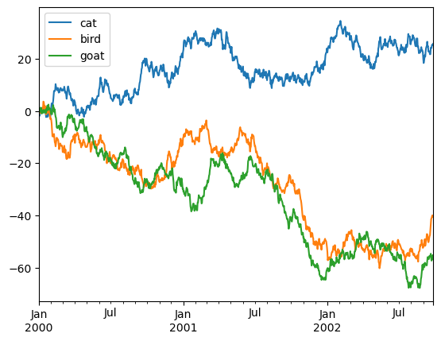

```python
df = pd.DataFrame(np.random.randn(1000, 3),
                  index=pd.date_range('1/1/2000', periods=1000),
                  columns=['cat','bird','goat'])
df_cumsum = df.cumsum()
_ = df_cumsum.plot()
```